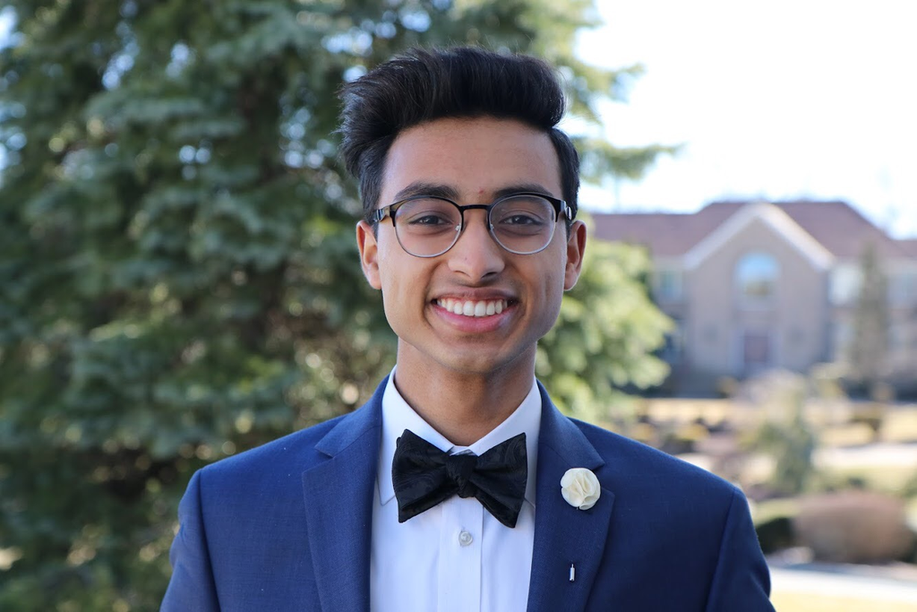

# Rahul Rana Investor, [SALT Fund](https://www.salt.org/) Author, [*Making Moonshots*](https://www.amazon.com/Making-Moonshots-Rahul-Rana/dp/163676620X) Writer, [Not Boring](https://www.notboring.co/)

## Bio

Rahul Rana is an Associate & Chief of Staff at [SALT Fund](https://www.salt.org/), a $200m AUM frontier tech venture capital firm spun out of SkyBridge Capital/SALT Conference. He currently writes for [Not Boring](https://www.notboring.co/), the 2nd largest business Substack with more than 200,000 subscribers. Previously, Rahul was a Summer Analyst at [General Atlantic](https://www.generalatlantic.com/) where he invested in growth equity with the BeyondNetZero climate and B2B Tech teams. Additionally, Rahul previously helped found [Arcadia Science](https://www.arcadiascience.com/), a frontier biotech research lab for which he raised $500m and focused on commercialization strategy. He also spent a year as a Venture Associate at [Lux Capital](https://luxcapital.com/), a $5bn deeptech venture capital firm at which Rahul sourced & diligenced startups related to space, life sciences, climate, national security, and crypto.

Rahul is the author of [Making Moonshots](https://www.amazon.com/Making-Moonshots-Rahul-Rana/dp/163676620X)—a deep dive into the mindsets, philosophies, and strategies conducive to building moonshot companies. “Moonshot company” entails three things: taking an advanced science or deep technology and using it in a radical solution to solve a big problem in the world.

He became intrigued by deeptech at an early age when he explored his father’s laboratory at the legendary Bell Labs. Rana has discovered the “ecosystem” of what makes a great moonshot company. He has transferred his fascination with researchers and startups that make giant leaps in scientific and technological progress into a prescription. His call to action for entrepreneurs is to embrace what appears at first glance to be impossible, but is actually quite practical when following the best mindsets and strategies harnessed by those who have come before.

In the past, Rahul has held operational roles at startups, venture partner/scout roles are top VC firms, and also interned in the NJ-6 Congressional District Office doing public policy work. Rahul graduated from Rutgers University where he studied Finance and Astrophysics.

## Content Library

*Featured interviews:*  
Rutgers University: You Might Recognize This Senior as the Face of Rutgers Business School ([Rutgers](https://www.rutgers.edu/news/you-might-recognize-senior-face-rutgers-business-school))

Business Insider: GEN Z VCS: Meet the top 29 up-and-comers changing the world of venture capital ([Business Insider](https://www.businessinsider.com/the-top-29-gen-z-vcs-changing-venture-capital-2021-2))

The Pomp Podcast: #480: Rahul Rana on Moonshot Ideas ([Apple Podcasts](https://podcasts.apple.com/us/podcast/480-rahul-rana-on-moonshot-ideas/id1434060078?i=1000506865254) // [YouTube](https://youtu.be/LQ60xXQNQLQ))

Business Insider: These are the 13 best books written by venture capitalists that every successful startup founder needs to read ([Business Insider](https://www.businessinsider.com/best-books-written-venture-capitalists-every-founder-needs-to-read-2021-3))

*2023*  
The Fusion Race ([Not Boring](https://www.notboring.co/p/the-fusion-race))

You Might Recognize This Senior as the Face of Rutgers Business School ([Rutgers](https://www.rutgers.edu/news/you-might-recognize-senior-face-rutgers-business-school))

Tell Good Stories ([Not Boring](https://www.notboring.co/p/tell-good-stories))

*2022*  
The Space Economy ([Not Boring](https://www.notboring.co/p/the-space-economy))

Making Moonshots ([Not Boring](https://www.notboring.co/p/making-moonshots))

Built In: I Pitched Jurassic Park to Investors. Here’s What They Said. ([BuiltIn](https://builtin.com/founders-entrepreneurship/jurassic-park-moonshot-investments))

*2021*  
UC Berkeley MBA PE/VC Club

Let’s Talk Venture: 0.5 - rahul rana ([Spotify](https://open.spotify.com/episode/01s6JnxO0o53mg7Sd96iG0?si=mgumiKsVR_KYX_PDMlARSg))

Deep Tech Insider: Deep Tech Dive #15 | Galvanizing Moonshots ([Medium](https://thedeeptechinsider.com/2021/08/12/deep-tech-dive-15-galvanizing-moonshots))

Canadian Undergraduate Technology Conference (CUTC) Speaker

Billion Moonshots Podcast

The Knowledge Society: Moonshot Hackathon judge

UC Berkeley Venture Capital Club: Fireside Chat

Creator Institute: Creators Fireside Chat

Sierra College: Young Investors Club chat

Undergraduate Venture Summit: panelist and host ([Website](https://www.runtheworld.today/app/invitation/24711))

The Knowledge Society: fireside chat ([Website](https://tks.world/))

TEDxLakeManalapan: Unveiling Ignorance: Shedding Light On The World ([TEDx](https://www.ted.com/tedx/events/41696))

OnDeck Catalyst: Founding Fellow ([OnDeck](https://www.beondeck.com/catalyst))

OurFuture: #125 Making Moonshots Author, Rahul Rana, on Writing a Book and Landing his Dream Job at Age 19 ([Apple Podcasts](https://podcasts.apple.com/us/podcast/125-making-moonshots-author-rahul-rana-on-writing-a/id1511226610?i=1000512806653) // [Spotify](https://open.spotify.com/episode/0ULCFTmdygw2ZnWRCqrpEA?si=NF3Tqu9pR3isR2tg7UV4Iw))

Business Insider: The future of NFTS: Gen Z VCs predict which industries will be transformed by non-fungible tokens ([Business Insider](https://www.businessinsider.com/8-gen-z-vcs-predict-the-future-of-nfts-2021-3))  
Member Almost Founders: MemberAF - Rahul Rana (Author and Associate at 20!) ([Spotify](https://open.spotify.com/episode/2xtpuk5enBi7nkISQKHa3e?si=l2bncHPrRPiKZKpyxZHwRg) // [Apple Podcasts](https://podcasts.apple.com/gb/podcast/almost-founders/id1537142326))

Jag Of All Trades: Making Moonshots or Mars-shots? How One Student is Pioneering the GenZ Venture Capital Scene ([Spotify](https://open.spotify.com/episode/3jnsm4YG5mePTksBGVoCaJ?si=ZWDkDzsNQji3gpYfU9Q1HQ))

The Change Alchemist: Rahul Rana, author of “Making Moonshots” talks about moonshot mindsets, radical creativity and strategies to build moonshot companies [(Apple Podcast](https://podcasts.apple.com/us/podcast/rahul-rana-author-making-moonshots-talks-about-moonshot/id1535365493?i=1000510528258s)

Driven By Doing: Creating the mindset and Making Moonshots | Rahul Rana ([YouTube](https://youtu.be/ZZ0kS9ZPgAA))

Network Capital: The Most Unconventional Way of Breaking Into Venture Capital with Rahul Rana ([Website](https://www.networkcapital.tv/course/unconventional-way-of-breaking-into-vc-with-rahul) // [Apple Podcasts](https://podcasts.apple.com/in/podcast/most-unconventional-way-breaking-into-venture-capital/id1473918423?i=1000505302991) // [Spotify](https://open.spotify.com/episode/3upqBYtGkYIC12owExJeUF?si=qHaW04MYSBWsy9Wwk1HSdA) // [Google Podcasts](https://podcasts.google.com/feed/aHR0cHM6Ly9hbmNob3IuZm0vcy8xZjM4N2EzOC9wb2RjYXN0L3Jzcw/episode/NmE4OWRmYWUtZTJlZS00YTJhLWI5ZTMtNGJkZWU1YzZkMWVk?))

Gen Z Mafia Fireside Chat

Broken Bulbs: Intentionally Balanced (017) ([Spotify](https://open.spotify.com/episode/60qI3rciFrLxDhYuzmwWAr?si=i-hFKfbPTUGZ5M4-YykFUg))

Dipper Research Partners: fireside chat

GenZScouts: fireside chat

Rutgers Venture Capital Club: fireside chat

STEM Time With Navya and Aishwarya: Interview with Author of Making Moonshots: Rahul Rana ([Spotify](https://open.spotify.com/episode/0OIztlZRvajw9LWlDwiHXy?si=QAdoCk8GQ8OrGc1HJRQXwQ))

*2020*  
ITSP Magazine + Elevate the Future: “Making Moonshots” And A Conversation About Deep Tech With Rahul Rana | Elevate The Future With Ellen Xu ([Website](https://itspmagazine.simplecast.com/episodes/making-moonshots-and-a-conversation-about-deep-tech-with-rahul-rana-elevate-the-future-with-ellen-xu-kXKO8XPJ))

Want Money Got Money with Sam Kamani: 50: What does it take to build a Moonshot with guest - Rahul Rana ([Spotify](https://open.spotify.com/episode/7pB9JmW6wfY2pZ7uF10qKP?si=is75EiIrRtyoJrr86JG0nQ) // [Apple Podcasts](https://podcasts.apple.com/nz/podcast/50-what-does-it-take-to-build-a-moonshot-with-guest-rahul-rana/id1524252647?i=1000514200691))

Marlboro High School TEDx Talk: The Case for Moonshots

Contrary Capital: Deeptech Funding Guide ([Contrary Blog](https://contrarycap.com/content/deeptech-funding-guide))

Build the Future Podcast: The Future of Moonshots, Venture, and Technology ([Spotify](https://open.spotify.com/episode/0otON2wOibIM8QtTqWKIWM?si=Jc41ILwsQ-mfjKz4KtWBIg))

Master Plan Newsletter: Secret Master Plan - Rahul Rana, Making Moonshots ([Substack](https://masterplan.substack.com/p/secret-master-plan-rahul-rana-making))

Rajit’s Show: Ep. #13 - Rahul Rana ([Apple Podcasts](https://podcasts.apple.com/us/podcast/ep-13-rahul-rana/id1547154924?i=1000505164557) // [Spotify](https://open.spotify.com/episode/4jsOsGBv60dmrPyplYZD8g?si=W0_595U9RZmWoziIbKAuzA))

Bexel FrontierTech Conference @ Northwestern University Kellogg MBA

The FWD Podcast: 469 - An Early Bet On Rahul Rana, Author of Making Moonshots ([Webpage](https://podcast.withfwd.com/469-an-early-bet-on-rahul-rana-author-of-making-moonshots) // [Apple](https://podcasts.apple.com/us/podcast/469-an-early-bet-on-rahul-rana-author-of-making-moonshots/id1454168902?i=1000502005577) // [Spotify](https://open.spotify.com/episode/4Jr1XJVsRrdEYSUudd0SPr?si=0A5JzXN3RuGcPxuydA311Q) // Google Podcasts)

Moonshot House: Gen Z’s Reinterpretation of VC, Episode 1 - The Case for Moonshots ([Kapwing](https://www.kapwing.com/videos/5fa30262a29bc40071743e76) // [LinkedIn](https://www.linkedin.com/in/rahul-rana-99b338169/detail/recent-activity/shares))

Heureka Group: Episode 22: An Exclusive Interview with Rahul Rana on “Making Moonshots” ([YouTube](https://youtu.be/JuHl3dBymDM))

GenZ Launch: EP 41: Interviewing Billionaires and Making Moonshots with Rahul Rana ([Apple Podcasts](https://podcasts.apple.com/us/podcast/ep-41-interviewing-billionaires-making-moonshots-rahul/id1513632738?i=1000497748869) // [Spotify](https://open.spotify.com/episode/3QAKBcE1rb4Cyky8KjUDuh?si=FyN54KlaSD-zey7APRi_Cg))

The New York Times: Gen Zers Say Silicon Valley Is Elitist and Exclusive. Can They Build a New System? ([NY Times](https://www.nytimes.com/2020/09/15/style/gen-z-tech-mafia.html))

Gritty & Curious: #21 - How to get an interview with a billionaire & How to write a book - Rahul Rana ([Apple Podcasts](https://podcasts.apple.com/us/podcast/21-how-to-get-interview-billionaire-how-to-write-book/id1508388626?i=1000477155821) // [Spotify](https://open.spotify.com/episode/3ERUvbO2ACyEQ2H1Ewdc6s?si=rUIAbgNOQkuiSjkwHnlCXQ))

& talks at Lehigh University, Open Water Accelerator, Northwestern University Kellogg School of Business (MBA), etc.

## Portfolio

64x Bio - Series A

Colossal - Series A

Anduril - Series E

Circa - Seed (Scout Investment)

Avro Life Science - Series A (Scout Investment)

## Experience

**Not Boring** | Writer | June 2022 - Present

**General Atlantic** | Summer Analyst | June 2022 - August 2022

**Arcadia Science** | Translational Strategy (and founding intern!) | September 2021 - June 2022

**Lux Capital** | Venture Associate | September 2020 - September 2021

## Education

**Rutgers University** | New Brunswick, NJ

**Finance & Astrophysics** | September 2019 - January 2023

## My book: *Making Moonshots*

In [*Making Moonshots*](https://www.amazon.com/Making-Moonshots-Rahul-Rana/dp/163676620X), investor and operator Rahul Rana asks the question: Why should we live in a world of incremental scientific and technological progress when the human race has proven in past eras that we are capable of so much more?

The world faces major problems. It is time for conventional thinkers to stand aside and give way to the crazy ones, the contrarians, the radically creative geniuses who work outside the box to create massive breakthroughs. In what is both a prescription for building successful deeptech startups and a call to arms to generate highly moral, deeply influential solutions that will positively affect the lives of billions, this book will teach you:

- The mindsets and philosophies of the greatest trailblazers of the past and present.
- Actionable strategies fueled by moonshot thinking.
- The complex ecosystem and all of its necessary moving parts for creating environments conducive to deeptech business operations.
- A tangible and reasonable course for entrepreneurs that will result in sustainable profitability and extraordinary global-changing results.

Rana predicts a new golden age is about to erupt in modern times. Dare to dream bigger. Let’s make some moonshots.

**Praise for *Making Moonshots:***  
“The outermost edges of science and technology hold huge potential. In Making Moonshots Rana writes inspiringly how our boldest, most necessary ideas are within reach, and how anyone can be on the path to reducing human suffering by way of entrepreneurial ventures. This book is a toolkit on how to do just that.” — Josh Wolfe, Co-founder and Managing Partner of Lux Capital

“By demystifying moonshots, Rahul puts them closer within reach. He makes a clear and compelling case for entrepreneurs to swing for the fences.” — Max Altman, Co-founder of Apollo Projects

“Where is the frontier? In his Endless Frontier, Vannevar Bush argued that scientific research alleviated ‘the burden of the common man for ages past.’ But in our time, with all the low-hanging fruit seemingly picked, where should society look for new advancements? The answer, as it was in ages past, is to invest in the bleeding edge of technology beyond software. For those looking to make a dent in the universe, Making Moonshots suggests that deep technology is our only viable option of going back to our Star-Trek future.” — Anirudh Pai, Partner at Dragonfly, a cross-border crypto fund ($3.5B+ AUM)

“This is an impressive contribution to a neglected but vital topic. Breakthrough technology holds the key to humanity’s fate over the next century. Rahul’s book is an illuminating guide for entrepreneurs who want to harness it for good.” — Matt Clifford, Co-founder and CEO of Entrepreneur First (EF) and Chair of ARIA, the UK’s Advanced Research and Invention Agency.

“Deeptech is so misunderstood, Rahul introduces us to it in a simpler sense. Making Moonshots covers what is commonly left out in tech startup books, you’ll explore what it really takes for a complicated organization to make it in a way that is fun and interesting.” — Adam Arafat, Author

“Making Moonshots details the rise of some of the most influential companies of our time, and perhaps of all time. Rahul explores the marriage of science and technology to create solutions that have altered the trajectory of mankind.” — Josh Lasky, Author

“Rahul brings us a new perspective on moonshot companies by exploring the ambition and mindset of prominent entrepreneurs.” — Julie Willis, Author

“In reading Making Moonshots, this is the kind of mindset we needed when addressing our recent global pandemic, COVID-19. I look forward to the ripple effect of change Rahul inspires through this book.” — Priyanka Surio, Author

“Making Moonshots makes deeptech accessible. If you’re looking for insight into the journeys of some of the most successful companies of the twenty-first century, and to avoid being bored out of your mind by a economics textbook, this is the perfect read for you and for anyone seeking knowledge-filled entertainment.” — Mackenzie Finklea, Author

“By cutting through the buzzwords that we now take for granted, Making Moonshots is a well-researched, articulate work on the role of technology, innovation, and venture capitalism in our 21st century society. Rana takes the reader on an interesting journey by sharing best practices and insights about an industry that can otherwise feel mysterious.” — Anjana Sreedhar, Author

“Rahul Rana makes a strong case for the societal and personal impacts of moonshot companies and radical creative thinking. Making Moonshots embodies the message that ‘the best way to predict the future is to create it,’ and the book provides clear and actionable insights on how to apply the moonshot mentality to one’s own dreams and ambitions, making it a valuable read for everyone.” — Shobha Dasari, Author of Hacking Healthcare

“If you have a moonshot in you, Rahul Rana will inspire you to make it a reality. He does a great job of helping you understand those intangibles of success, when beginning your tech startup journey, that no one tells you about.” — Rahul Prakash, Author of Unblocking Blockchain